# Lesson 3

### What to Do First?

Notes:

### Pseudo-Facebook User Data

Notes:

### Histogram of Users’ Birthdays

Notes:

```r
#install.packages('ggplot2')
#library(ggplot2)
```

#### What are some things that you notice about this histogram?

Response:

### Moira’s Investigation

Notes:

### Estimating Your Audience Size

Notes:

#### Think about a time when you posted a specific message or shared a photo on Facebook. What was it?

Response:

#### How many of your friends do you think saw that post?

Response:

#### Think about what percent of your friends on Facebook see any posts or comments that you make in a month. What percent do you think that is?

Response:

### Perceived Audience Size

Notes:

### Faceting

Notes:

```r
library(ggplot2)
fb <- read.csv(file= 'pseudo_facebook.tsv',sep='\t')

table(fb$gender)
```

```
##
## female   male
##  40254  58574
```

```r
by(fb$friend_count, fb$gender, mean)
```

```
## fb$gender: female
## [1] 241.9699
## --------------------------------------------------------
## fb$gender: male
## [1] 165.0355
```

#### Letâs take another look at our plot. What stands out to you here?

Response:

### Be Skeptical - Outliers and Anomalies

Notes:

### Friend Count

Notes:

#### What code would you enter to create a histogram of friend counts?

#### How is this plot similar to Moira’s first plot?

Response:

### Limiting the Axes

Notes:

### Exploring with Bin Width

Notes:

### Adjusting the Bin Width

Notes:

### Faceting Friend Count

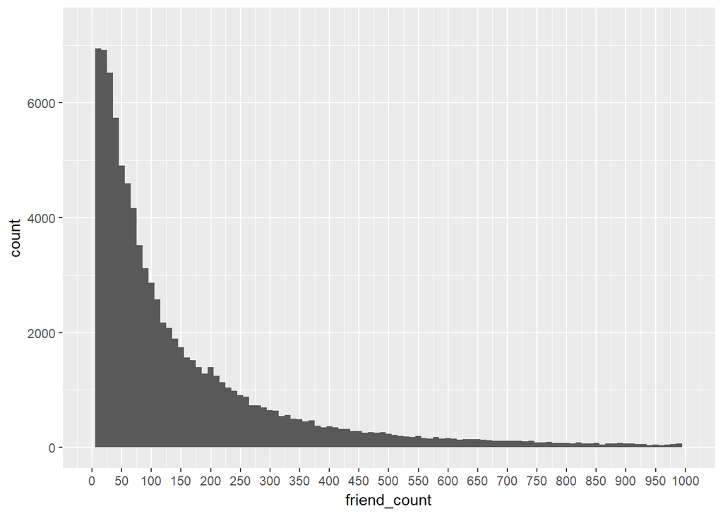

```r
# What code would you add to create a facet the histogram by gender?
# Add it to the code below.
qplot(x = friend_count, data = fb, binwidth = 10) +
  scale_x_continuous(limits = c(0, 1000),
                     breaks = seq(0, 1000, 50))
```

### Omitting NA Values

Notes:

### Statistics ‘by’ Gender

Notes:

#### Who on average has more friends: men or women?

Response:

#### What’s the difference between the median friend count for women and men?

Response:

#### Why would the median be a better measure than the mean?

Response:

### Tenure

Notes:

[figure not shown]

```r
#print(fb$tenure)

#Output for Tenure as is

qplot(x = na.omit(fb$tenure), binwidth = 25,
      color = I('black'), fill = I('#00ff00'), xlab = 'Tenure in Years')+
  scale_x_continuous(breaks = 0:7)
```

```r
#ggplot(data = fb) +
#  geom_histogram(aes(tenure),binwidth = 25)
```

#### How would you create a histogram of tenure by year?

```r
library(ggthemes)
?seq()
```

```
## starting httpd help server ... done
```

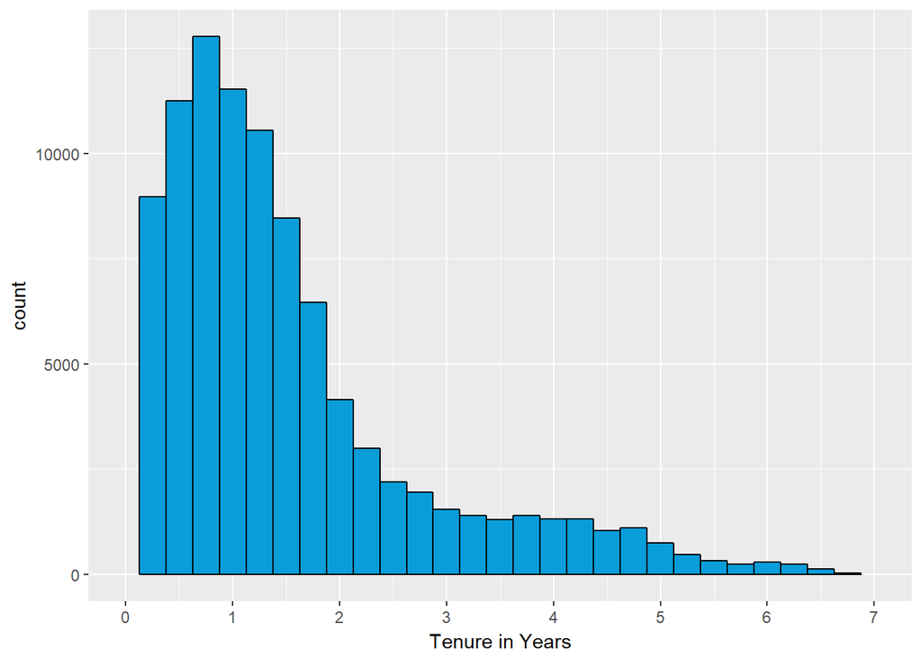

```r
#Output for tenure with NA and in Years

a <- na.omit(fb$tenure)

qplot(x = (a/365), binwidth = 0.25,
      color = I('black'), fill = I('#099DD9'), xlab = 'Tenure in Years')+
  scale_x_continuous(breaks = 0:7, limits = c(0,7))
```

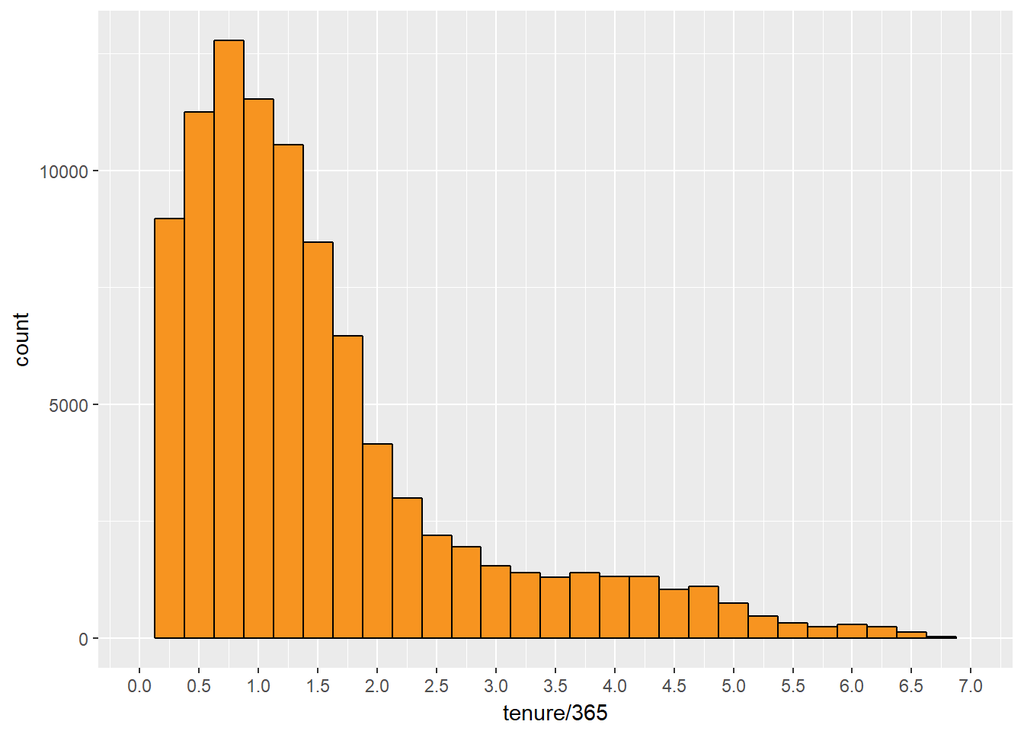

```r
ggplot(aes(x = tenure/365), data = fb) +
  geom_histogram(binwidth = .25, color = 'black', fill = '#F79420')+
  scale_x_continuous(breaks = seq(0, 7, 0.5), limits = c(0,7))
```

### Labeling Plots

Notes:

### User Ages

Notes:

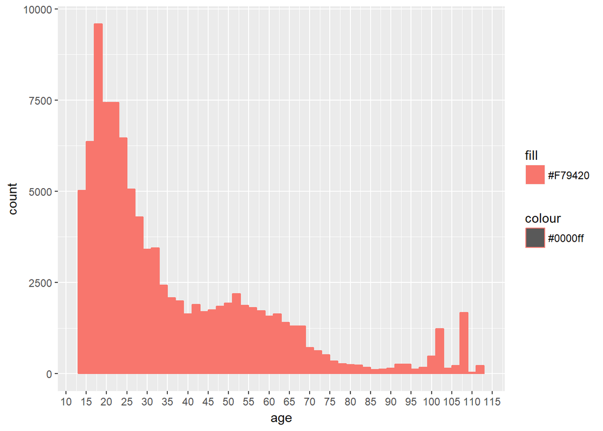

```r
qplot(x = age, data = fb, binwidth = 2,color = '#0000ff', fill = '#F79420')+
  scale_x_continuous(breaks = seq(0,120,5))
```

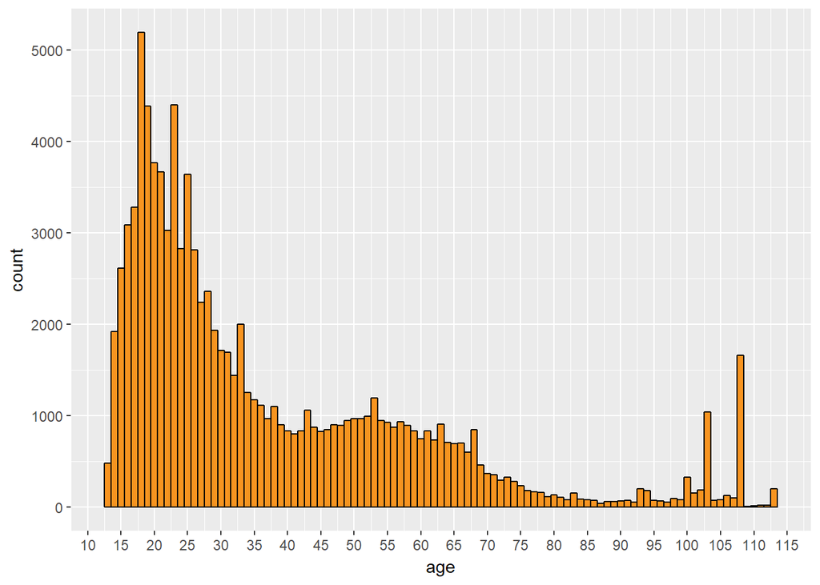

```r
ggplot(aes(x = age), data = fb) +
  geom_histogram(binwidth = 1, color = 'black', fill = '#F79420')+
  scale_x_continuous(breaks = seq(0, 120, 5))
```

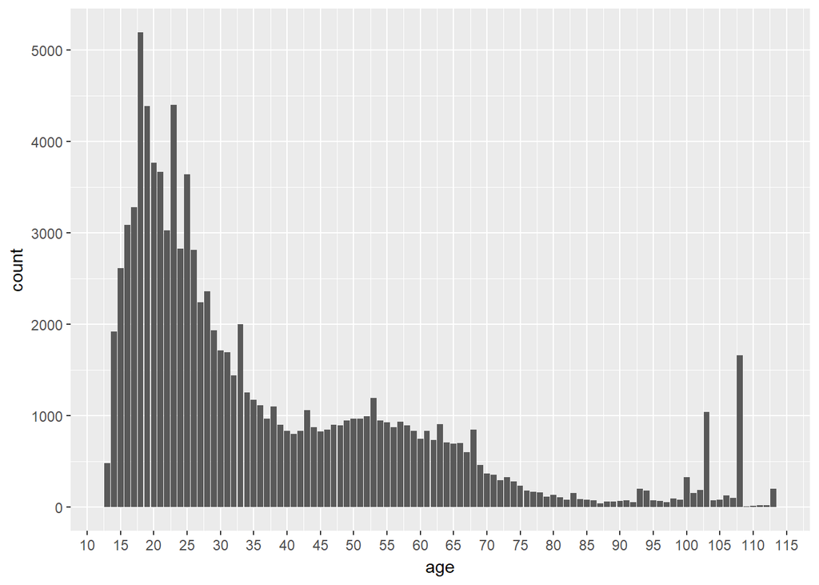

```r
ggplot(aes(x = age), data = fb) +
  geom_bar()+
  scale_x_continuous(breaks = seq(0, 120, 5))
```

### The Spread of Memes

Notes:

### Lada’s Money Bag Meme

Notes:

### Transforming Data

Notes:

```r
print('Regular Summary')
```

```
## [1] "Regular Summary"
```

```r
summary(fb$friend_count)
```

```
##    Min. 1st Qu.  Median    Mean 3rd Qu.    Max.
##     0.0    31.0    82.0   196.4   206.0  4923.0
```

```r
print('log10 Summary')
```

```
## [1] "log10 Summary"
```

```r
summary(log10(fb$friend_count + 1))
```

```
##    Min. 1st Qu.  Median    Mean 3rd Qu.    Max.
##   0.000   1.505   1.919   1.868   2.316   3.692
```

```r
print('SQRT Summary')
```

```
## [1] "SQRT Summary"
```

```r
summary(sqrt(fb$friend_count))
```

```
##    Min. 1st Qu.  Median    Mean 3rd Qu.    Max.
##   0.000   5.568   9.055  11.088  14.353  70.164
```

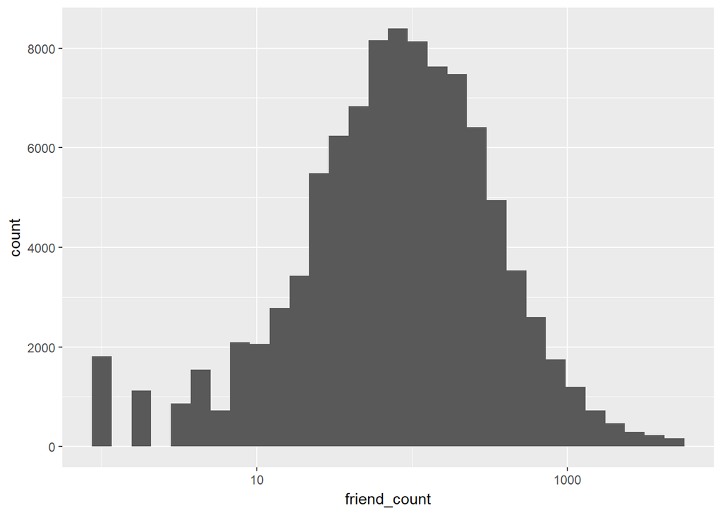

```r
qplot(x = friend_count, data = fb)+
  scale_x_log10()
```

***

### Add a Scaling Layer

Notes:

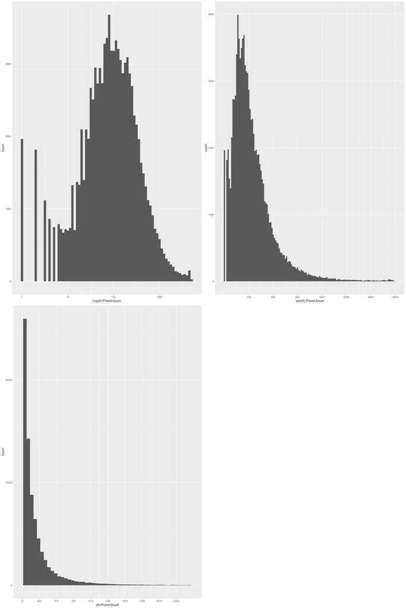

```r
library(ggplot2)
library(gridExtra)
library(scales)
?trans_breaks
?scale_x_log10

p1 = ggplot(aes(x = (friend_count+1)), data = fb)+
  geom_histogram(binwidth = 0.05)+
  scale_x_log10(breaks = trans_breaks("log10", function(x) 10^(x)))+
  labs(x = 'Log(X) Friend Count')

p2 = ggplot(aes(x = (friend_count)), data = fb)+
  geom_histogram(binwidth = 0.5)+
  scale_x_sqrt(breaks = trans_breaks("sqrt", function(x) x ^ 2))+
  labs(x = 'sqrt(X) Friend Count')

p3 = ggplot(aes(x = (friend_count)), data = fb)+
  geom_histogram(binwidth = 50)+
  scale_x_continuous(breaks = seq(10,2500,250), limits = c(10,2500))+
  labs(x = '(X) Friend Count')

grid.arrange(p1, p2, p3, ncol=2)
```

### Frequency Polygons

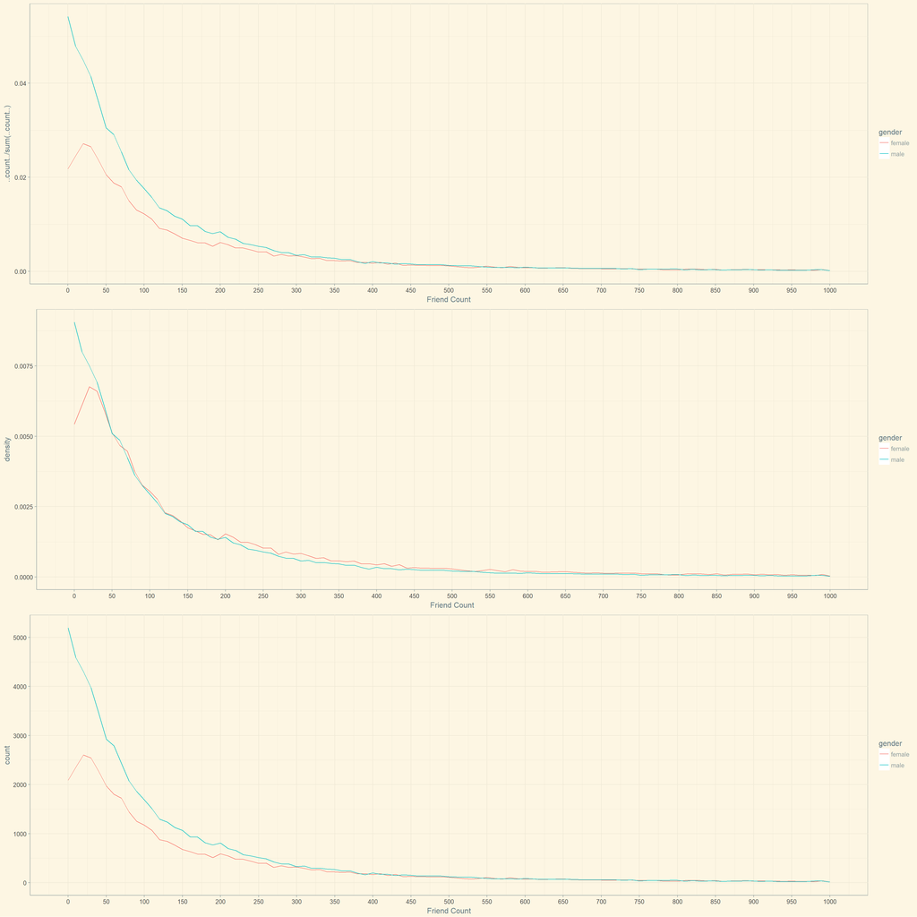

```r
library(ggthemes)

p4 = ggplot(aes(x = friend_count, y = ..count../sum(..count..)), data = subset(fb, !is.na(gender)))+
  geom_freqpoly(aes(color = gender), binwidth = 10)+
  scale_x_continuous(limits = c(0,1000), breaks = seq(0,1000,50))+
  xlab('Friend Count')+
  theme_solarized()

p5 = ggplot(aes(x = friend_count, y = ..density..), data = subset(fb, !is.na(gender)))+
  geom_freqpoly(aes(color = gender), binwidth = 10)+
  scale_x_continuous(limits = c(0,1000), breaks = seq(0,1000,50))+
  xlab('Friend Count')+
  theme_solarized()

p6 = ggplot(aes(x = friend_count), data = subset(fb, !is.na(gender)))+
  geom_freqpoly(aes(color = gender), binwidth = 10)+
  scale_x_continuous(limits = c(0,1000), breaks = seq(0,1000,50))+
  xlab('Friend Count')+
  theme_solarized()

grid.arrange(p4, p5,p6, ncol = 1)
```

### Likes on the Web

Notes:

### Box Plots

Notes:

#### Adjust the code to focus on users who have friend counts between 0 and 1000.

### Box Plots, Quartiles, and Friendships

Notes:

#### On average, who initiated more friendships in our sample: men or women?

Response:

### Getting Logical

Notes:

Response:

### Analyzing One Variable

Reflection:

Click **KnitHTML** to see all of your hard work and to have an html page of this lesson, your answers, and your notes!